# NYPD Fatal Shooting Rates

–

9/2/2021

## Packages Used

In this report we will use the tidyverse package for R. If you wish to install the package you can visit https://www.tidyverse.org/packages/ and follow the instructions.

```r
library(tidyverse)
```

## Data Set

We will start by importing our data set from the source website. We use read_csv() instead of read.csv() as the former is more efficient when handling a large csv file.

Our csv file contains data on shootings withing the city of New York from 2006 to the end of 2020. This data is manually extracted every quarter by the Office of Management Analysis and Planning and is available on the NYPD website. Each row represents a separate shooting and includes information about the event, location, time of occurrence and information related to suspect and victim demographics.

Using the spec function we can see the specific categories contained within the data set and utilizing head() we can get a brief preview of the data set.

```r
url_in <- "https://data.cityofnewyork.us/api/views/833y-fsy8/rows.csv?accessType=DOWNLOAD"
nypd_shooting_init_dataset <- read_csv(url_in, na = '')
```

```r
spec(nypd_shooting_init_dataset)
head(nypd_shooting_init_dataset)
```

```
## # A tibble: 6 x 19
##   INCIDENT_KEY OCCUR_DATE OCCUR_TIME BORO          PRECINCT JURISDICTION_CODE
##          <dbl> <chr>      <chr>      <chr>            <dbl>             <dbl>
## 1    201575314 08/23/2019 22:10:00   QUEENS             103                 0
## 2    205748546 11/27/2019 15:54:00   BRONX               40                 0
## 3    193118596 02/02/2019 19:40:00   MANHATTAN           23                 0
## 4    204192600 10/24/2019 00:52:00   STATEN ISLAND      121                 0
## 5    201483468 08/22/2019 18:03:00   BRONX               46                 0
## 6    198255460 06/07/2019 17:50:00   BROOKLYN            73                 0
## # ... with 13 more variables: LOCATION_DESC <chr>,
## #   STATISTICAL_MURDER_FLAG <lgl>, PERP_AGE_GROUP <chr>, PERP_SEX <chr>,
## #   PERP_RACE <chr>, VIC_AGE_GROUP <chr>, VIC_SEX <chr>, VIC_RACE <chr>,
## #   X_COORD_CD <dbl>, Y_COORD_CD <dbl>, Latitude <dbl>, Longitude <dbl>,
## #   Lon_Lat <chr>
```

## Cleaning the Data set

For this report we are looking at the fatality rates of the various shootings over time and by year.

To start out we will get rid of columns that will not be used in our analyses such as INCIDENT_KEY, PERP_RACE, LATITUDE, LONGITIUDE, etc using the dplyr package which is included in tinyverse. We will check the new data set using head() and summary().

We will clean the data in two separate ways for the purpose of our analysis. First we will look at the overall rate of shootings being fatal over the entire time period (2006 - 2020). To do this we will group the data by borough and then calculate the overall frequency of a shooting resulting in a fatality.

After this we will go back to our initially modified data set and analyze the trend of fatal shooting rates by the year. First we will clean up the OCCUR_DATE column by grouping the dates by year.Then we will get the frequency per year per borough and plot them as a line graph.

```r
fatality_dataset <- nypd_shooting_init_dataset %>% select('BORO', 'STATISTICAL_MURDER_FLAG', 'OCCUR_DATE')
```

```r
head(fatality_dataset)
```

```
## # A tibble: 6 x 3
##   BORO          STATISTICAL_MURDER_FLAG OCCUR_DATE
##   <chr>         <lgl>                   <chr>
## 1 QUEENS        FALSE                   08/23/2019
## 2 BRONX         FALSE                   11/27/2019
## 3 MANHATTAN     FALSE                   02/02/2019
## 4 STATEN ISLAND TRUE                    10/24/2019
## 5 BRONX         FALSE                   08/22/2019
## 6 BROOKLYN      FALSE                   06/07/2019
```

```r
summary(fatality_dataset)
```

```
##      BORO           STATISTICAL_MURDER_FLAG  OCCUR_DATE
##  Length:23568       Mode :logical           Length:23568
##  Class :character   FALSE:19080             Class :character
##  Mode  :character   TRUE :4488              Mode  :character
```

## Rate a shooting was Fatal in each Borough (2006 -2020)

```r
fatality_by_boro_dataset <-  fatality_dataset %>%  group_by(BORO, STATISTICAL_MURDER_FLAG) %>%   summarise(n = n()) %>%
  mutate(freq = n / sum(n))
fatality_by_boro_dataset <-  fatality_by_boro_dataset[fatality_by_boro_dataset$STATISTICAL_MURDER_FLAG != FALSE, ]
fatality_by_boro_dataset
```

```
## # A tibble: 5 x 4
## # Groups:   BORO [5]
##   BORO          STATISTICAL_MURDER_FLAG     n  freq
##   <chr>         <lgl>                   <int> <dbl>
## 1 BRONX         TRUE                     1244 0.186
## 2 BROOKLYN      TRUE                     1892 0.195
## 3 MANHATTAN     TRUE                      512 0.175
## 4 QUEENS        TRUE                      697 0.198
## 5 STATEN ISLAND TRUE                      143 0.205
```

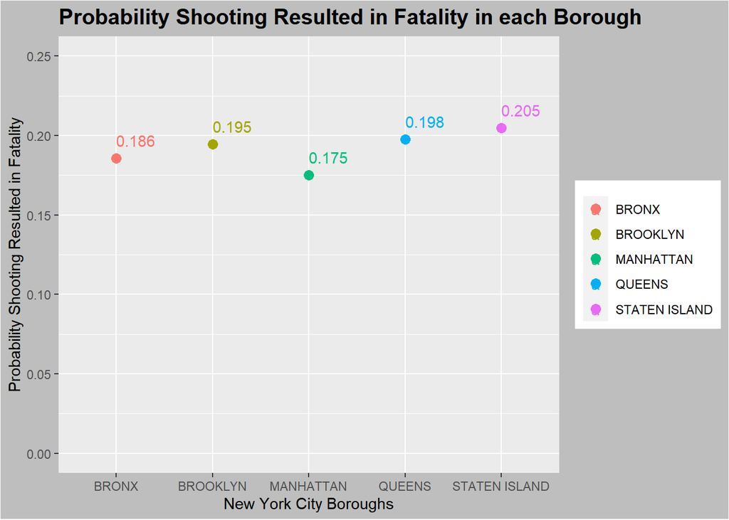

## Rate a shooting was Fatal in each Borough per year (2006 - 2020)

```r
fatality_by_by_dataset <- fatality_dataset
fatality_by_by_dataset$YEAR <- format(as.Date(fatality_by_by_dataset$OCCUR_DATE, format="%m/%d/%Y"),"%Y")
fatality_by_by_dataset <- select(fatality_by_by_dataset, -OCCUR_DATE)
fatality_by_by_dataset <-  fatality_by_by_dataset %>%  group_by(BORO, YEAR, STATISTICAL_MURDER_FLAG) %>%   summarise(n = n()) %>%
  mutate(freq = n / sum(n))
fatality_by_by_dataset <-  fatality_by_by_dataset[fatality_by_by_dataset$STATISTICAL_MURDER_FLAG != FALSE, ]
head(fatality_by_by_dataset)
```

```
## # A tibble: 6 x 5
## # Groups:   BORO, YEAR [6]
##   BORO  YEAR  STATISTICAL_MURDER_FLAG     n  freq
##   <chr> <chr> <lgl>                   <int> <dbl>
## 1 BRONX 2006  TRUE                      137 0.241
## 2 BRONX 2007  TRUE                       93 0.174
## 3 BRONX 2008  TRUE                       89 0.171
## 4 BRONX 2009  TRUE                       98 0.185
## 5 BRONX 2010  TRUE                       96 0.183
## 6 BRONX 2011  TRUE                      114 0.200
```

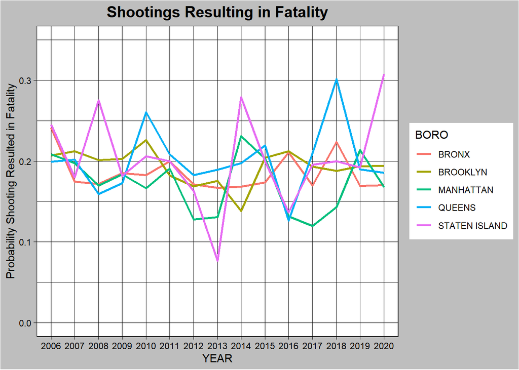

## Results

From our data we can see a few trends. The first is that the Bronx has a relatively stable probability, from 2007 - 2020, for a shooting to result in a fatality. Another interesting trend we notice is that in 2020 all the boroughs, excluding Staten Island, have a similar probability of a shooting being fatal. Staten Island in 2020, on the other hand, actually has the highest value seen in the 15 year period for the likelihood of a shooting resulting in a fatality. Due to hospitals being overrun and at maximum capacity during the COVID-19 pandemic, we could expect there to be a rise in the fatality rates, however we only see that with one borough. Finally we can observe that in 2012/2013 all the boroughs either dipped in probability or stayed flat. This is an event that we see only one other time from the beginning of our data set in 2006/2007.

## Bias and Conclusion

As someone from the suburbs, I have a preconceived bias regarding the safety of big cities, especially New York. If I only looked at the average over the fifteen years of data, I could quickly come to the conclusion that all areas of the city have a similar rate of shootings being fatal. However, to counter this I looked year by year and this shows us that there are trends in each borough and that they are not one in the same. Another potential source of bias is how they defined a shooting being fatal. Does it count if the individual died on the operating table, due to surgical error, after they were brought to the nearby trauma center/emergency room? What if the shooting resulted in infection which then later killed the victim? If there is a borough with more experienced/well equipped trauma centers, relative to the others, we can expect said borough to have less surgical errors when treating victims and therefore less deaths. Without knowing the criteria and methodology for categorizing certain variables it is possible that bias has creeped in.